# MA615hw1

Wenting Chen

2023-09-11

In this homework I’m analyzing a small subset of the IPUMS dataset. I start by loading the packages and the data.

```r
library(tidyverse)
library(ggthemes)
load("~/Desktop/MA615/ma-4615-fa2023-hw-1-coriandercwt/ipums_hw_data.RData")
ipums_hw_data
```

```
## # A tibble: 2,798 × 8
##     YEAR  SERIAL  PERWT HHINCOME RACE  RACED POVERTY SPMPOV
##    <int>   <dbl>  <dbl>    <dbl> <fct> <fct>   <dbl> <fct>
##  1  2013  782791  5215.    30000 White White     127 In poverty
##  2  2014 1045362 12573    145000 White White     501 Not in poverty
##  3  2013  436423 11906.   185204 White White     501 Not in poverty
##  4  2010 1183930  8089.   133000 White White     501 Not in poverty
##  5  2016  976108  8428.   165000 White White     501 Not in poverty
##  6  2011  556094  9900     92000 White White     407 In poverty
##  7  2016 1214893  7424.   120000 White White     422 Not in poverty
##  8  2013  675831  8167.    92700 White White     299 Not in poverty
##  9  2012   29649  6401.   122000 White White     443 Not in poverty
## 10  2018 1373978  4001.    76000 White White     501 Not in poverty
## # ℹ 2,788 more rows
```

Descriptions for the variables in the data set are given below.

[output not shown]

## Question 1

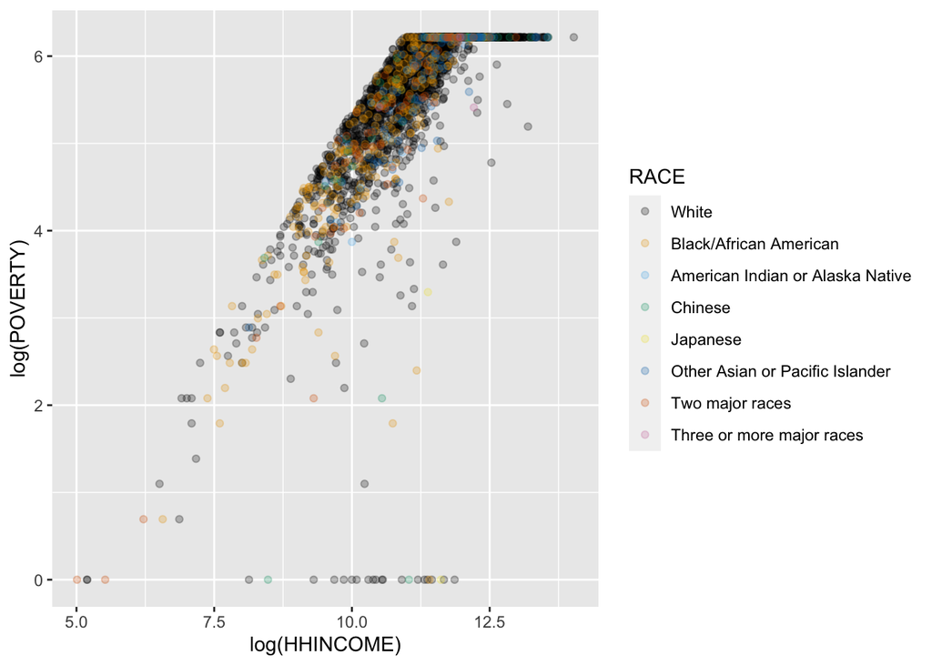

```r
ggplot(ipums_hw_data, aes(x = log(HHINCOME), y = log(POVERTY), color = RACE)) +
  geom_point(alpha = 0.25) +
  scale_color_colorblind()
```

## Question 2

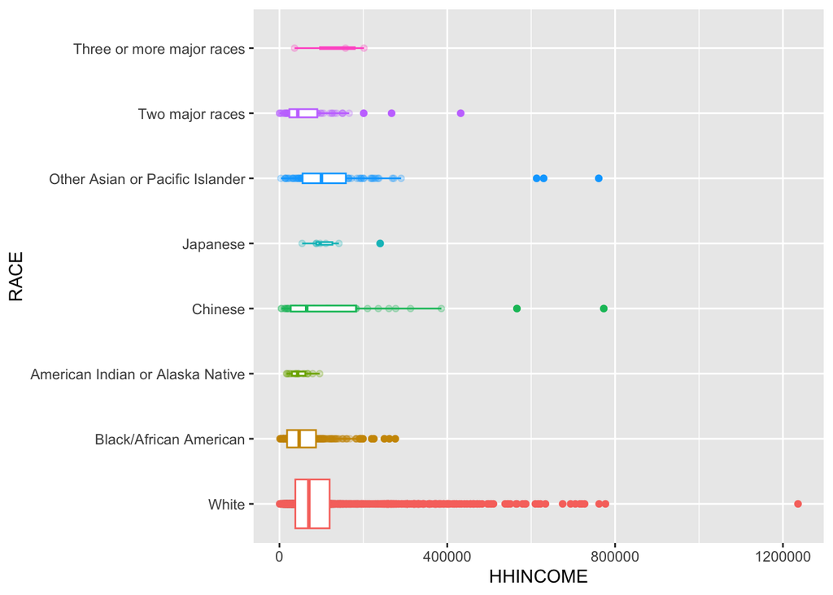

```r
ggplot(ipums_hw_data, aes(x = HHINCOME, y = RACE, color = RACE)) +
  geom_point(alpha = 0.25) + scale_color_colorblind() +
  geom_boxplot(varwidth = TRUE) +
  scale_color_discrete(guide = guide_none())
```

## Question 3

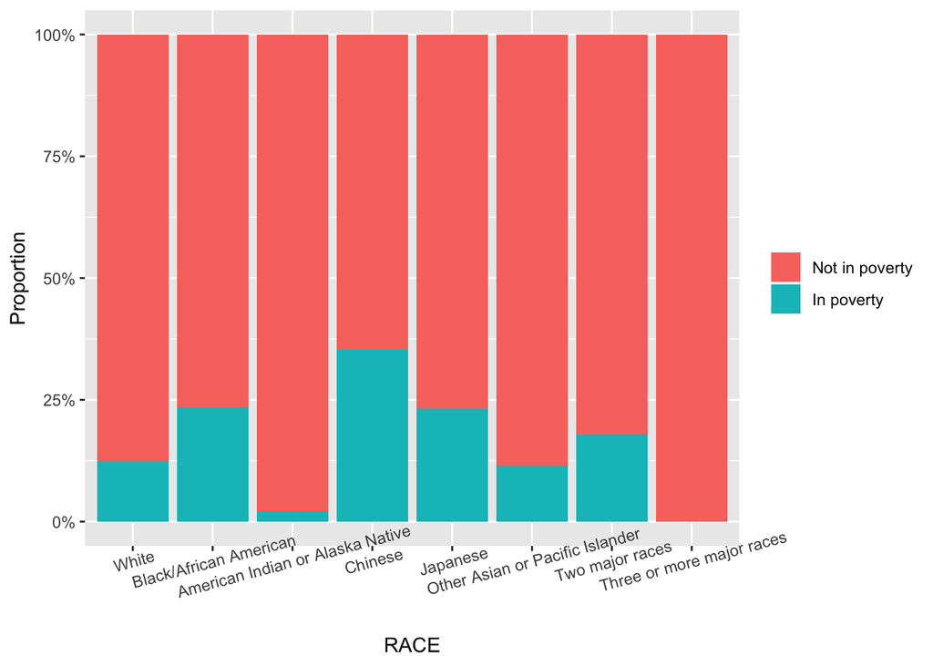

```r
ggplot(ipums_hw_data, aes(x = RACE, fill = SPMPOV, weight = PERWT))+geom_bar(position = "fill") +
  labs(y = "Proportion") + scale_y_continuous(labels = scales::percent_format()) +
  theme(axis.text.x = element_text(angle = 15)) + scale_fill_discrete(name=NULL)
```

geom_bar(position = “fill”): This command creates a bar chart (geom_bar) using the position = “fill” parameter. When position=“fill” is set, this means that the height of the bars will be adjusted so that they each represent a proportion of the total for each group, where each bar represents the relative distribution of categories within the group. aes(weight = PERWT): This directive means that the height of each bar will be determined by the sum of the PERWT values within each category, which ensures that the bars represent weighted counts or proportions. When these two directives are combined, a stacked bar chart is created in which the height of each bar represents the proportion of categories in the group, and this proportion is weighted by the PERWT value. This is a way to visualize the distribution of categorical variables while taking into account the weight of the data.

## Question 4

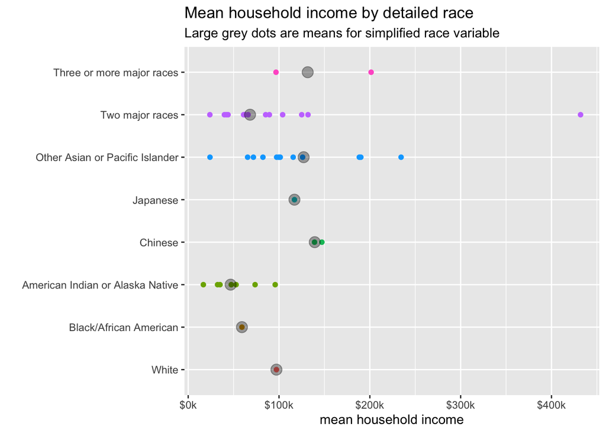

```r
Raced_mean <- aggregate(HHINCOME ~ RACE + RACED, data = ipums_hw_data, FUN = mean)
ggplot(ipums_hw_data, aes(x = HHINCOME, y = RACE, color = RACE)) +
  geom_point(data = Raced_mean, aes(x = HHINCOME, y = RACE)) +
  scale_x_continuous(labels = scales::dollar_format(prefix = "$", suffix = "k", scale = 0.001)) +
  stat_summary(fun  = "mean", geom = "point", color = "black", size = 4, alpha = 0.35) +
  labs(title = "Mean household income by detailed race", subtitle = "Large grey dots are means for simplified race variable", x = "mean household income", y = "") +
  scale_color_discrete(guide = guide_none())
```